# 2024 UK General Election Turnout Analysis

Investigating voter participation patterns

Sumer Gupta (University of Essex)  
2026-02-19

```r
library(stringr)
library(readr)
library(ggplot2)
library(curl)
library(tidyverse)
```

## Introduction

This project aims to study the UK 2024 General Election, specifically, it investigates the low turnout across the constituencies of the UK. It uses a [data-set](https://electionresults.parliament.uk/general-elections/6/candidacies.csv) obtained from the UK parliament.

## 1. Cleaning the Data-set

```r
uk_csv <- "https://electionresults.parliament.uk/general-elections/6/candidacies.csv"
uk_raw <- readr::read_csv(uk_csv, show_col_types = FALSE)
names(uk_raw) <- names(uk_raw) %>% tolower() %>% str_replace_all("\\s+", "_")

# By-elections are filtered out so that only general election constituencies remain in the data.

uk1 <- uk_raw %>%
  filter(!`election_is_by-election`)

# Selected columns are renamed for clarity and stored into uk2

uk2 <- uk1 %>%
  select(
    constituency = constituency_name,
    country = country_name,
    valid_votes = candidate_vote_count,
    electorate = electorate
  )

# Group the data by country and constituency

uk3 <- uk2 %>%
  group_by(country, constituency) %>%
  summarise(
    valid_votes = sum(valid_votes, na.rm = TRUE),
    electorate = max(electorate, na.rm = TRUE),
    .groups = "drop"
  )

# Calculate turnout and filter out invalid votes

uk <- uk3 %>%
  mutate(turnout_registered = 100 * valid_votes / electorate) %>%
  filter(is.finite(turnout_registered), electorate > 0)
```

This code processes the official data, it takes the raw data-set and standardizes the column names for easier manipulation. After filtering out by-elections to focus exclusively on general election results, the script aggregates candidate-level data to determine the total valid votes and maximum electorate for each constituency. Then, it calculates the voter turnout as a percentage of the registered electorate; transforming granular candidate information into a high-level geographical summary. Finally, data integrity is maintained by removing entries with invalid/empty entries to maintain a clean data-set that is ready for comparative analysis

## 2. Visualization (A): Mean Turnout and Distribution by Country

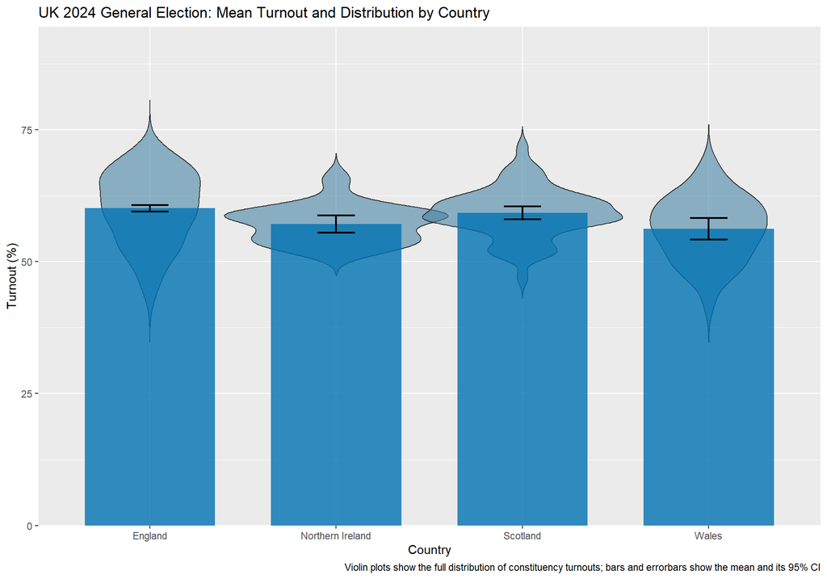

```r
# Calculate the standard error (se) and confidence intervals (ci)
turnout_by_country_ci <- uk %>%
  group_by(country) %>%
  summarise(mean_turnout = mean(turnout_registered, na.rm = TRUE),
            median_turnout = median(turnout_registered,
                                    na.rm = TRUE),
            sd_turnout = sd(turnout_registered, na.rm = TRUE),
            n = n(),
            .groups = "drop") %>%
  # summarises the mean and median turnout, standard deviation and sample size for each
  mutate(
    se = sd_turnout / sqrt(n),
    ci_lower = mean_turnout - 1.96 * se,
    ci_upper = mean_turnout + 1.96 * se
    ) #modifies the columns in the existing dataset (SE, CI bounds)


# Create the visualisation using ggplot2
# The first layer - a violin plot showing the full distribution
ggplot(uk, aes(country, turnout_registered)) +
  geom_violin(fill = "#4884a5", alpha = 0.6, trim = FALSE, width = 1.2) +
# The second layer - the bar chart of mean turnout
  geom_col(data = turnout_by_country_ci, aes(y = mean_turnout),
           width = 0.7, fill = "#0072B2", alpha = 0.8) +
# The third layer - error bars showing the confidence intervals
  geom_errorbar(data = turnout_by_country_ci,
                aes(y = mean_turnout,
                    ymin = ci_lower, ymax = ci_upper),
                width = 0.2, size = 0.8) +
  scale_y_continuous(name = "Turnout (%)",
                     limits = c(0,90),
                     expand = expansion(mult = c(0, 0.05))
                     ) +
  labs(
    title = "UK 2024 General Election: Mean Turnout and Distribution by Country",
    x = "Country",
caption = "Violin plots show the full distribution of constituency turnouts; bars and errorbars show the mean and its 95% CI"
  )
```

## 3. Visualization (B): Differences in Constituency Sizes across Nations of the UK

[figure not shown]

```r
# Calculate the overall mean turnout for all of UK
overall_mean <- mean(uk$valid_votes)

# Create the visualisation using ggplot2
# The first layer - the density plot
ggplot(uk, aes(x = valid_votes)) +
  geom_density(aes(fill=country), alpha = 0.67) +
  # The second layer - vertical line showing the overall mean
  geom_vline(xintercept = overall_mean,
             color = "red", linetype = "dashed", linewidth = 1) +
  # Separate the plots by country
  facet_wrap(~ country, scales = "free_y") +
  scale_fill_brewer(palette = "Set2", guide = "none") +
  labs(
    title = "How do Constituency Sizes Differ Across the Nations of the UK",
    subtitle = "A comparison of the number of voters in each constituency \nacross England, Scotland, Wales and Northern Ireland",
    y = "Number of Valid Votes per Constituency",
    x = "Density (How Common Each Size Is)"
  ) +
  theme_classic() +
  theme(
    plot.title = element_text(face = "bold", size = 14),
    strip.text = element_text(face = "bold")
  )
```

This graph shows that Northern-Ireland has the most equal-sized constituencies, as the base of the curve covers the shortest range on the x-axis (narrowest spread) - roughly 30,000 to 55,000 valid votes. Whereas, Scotland has the most unequal-sized constituencies, as the base of the curve is widest with a gradual tail that extends below 20,000 valid voters on the x-axis.

Such a density plot automatically normalizes the distribution, such that the area under each curve sums to 1, regardless of the number of constituencies within each country. The `geom_density()` function uses the underlying computation of a kernel density estimator, which assumes that the underlying distribution in the data is unbounded, smooth and continuous. Such a visualization can handle the larger sample size, as it automatically uses the number of observations to estimate the curve. It is also good at visualizing the spread as it has a single visual measure, so inequality can be inferred from looking at the width of the curve at its base.